# Resolucion TP 1

```r
install.packages("readr")  # For reading CSV files
library(readr)
# Cargar las librerías necesarias
library(tidyverse)
library(ggplot2)
```

```r
# Define file path (update if necessary)
file_path <- "dirty_cafe_sales.csv"

# Read the CSV file into an R dataframe
cafe_sales_df <- read_csv(file_path)
head(cafe_sales_df)
```

| Transaction ID | Item | Quantity | Price Per Unit | Total Spent | Payment Method | Location | Transaction Date |
| --- | --- | --- | --- | --- | --- | --- | --- |
| TXN_1961373 | Coffee | 2 | 2.0 | 4.0 | Credit Card | Takeaway | 2023-09-08 |
| TXN_4977031 | Cake | 4 | 3.0 | 12.0 | Cash | In-store | 2023-05-16 |
| TXN_4271903 | Cookie | 4 | 1.0 | ERROR | Credit Card | In-store | 2023-07-19 |
| TXN_7034554 | Salad | 2 | 5.0 | 10.0 | UNKNOWN | UNKNOWN | 2023-04-27 |
| TXN_3160411 | Coffee | 2 | 2.0 | 4.0 | Digital Wallet | In-store | 2023-06-11 |
| TXN_2602893 | Smoothie | 5 | 4.0 | 20.0 | Credit Card | NA | 2023-03-31 |

```r
NA
```

```
[1] "Resumen de casos especiales"
[1] "Item"
```

| NA_count | ERROR_count | UNKNOWN_count |
| --- | --- | --- |
| 333 | 292 | 344 |

```
-------------------------------------------------------
[1] "Resumen de casos especiales"
[1] "Quantity"
```

| NA_count | ERROR_count | UNKNOWN_count |
| --- | --- | --- |
| 138 | 170 | 171 |

```
-------------------------------------------------------
[1] "Resumen de casos especiales"
[1] "Payment Method"
```

| NA_count | ERROR_count | UNKNOWN_count |
| --- | --- | --- |
| 2579 | 306 | 293 |

```
-------------------------------------------------------
[1] "Resumen de casos especiales"
[1] "Location"
```

| NA_count | ERROR_count | UNKNOWN_count |
| --- | --- | --- |
| 3265 | 358 | 338 |

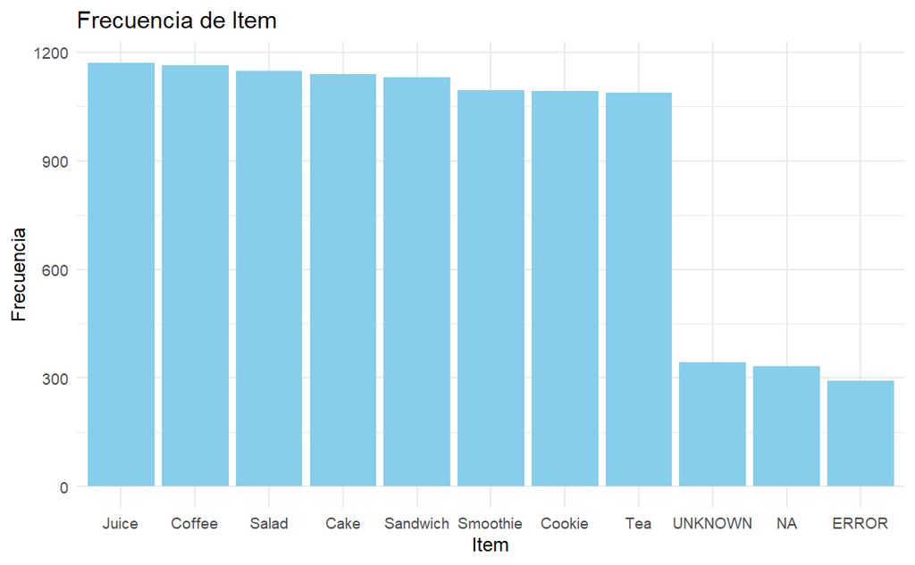

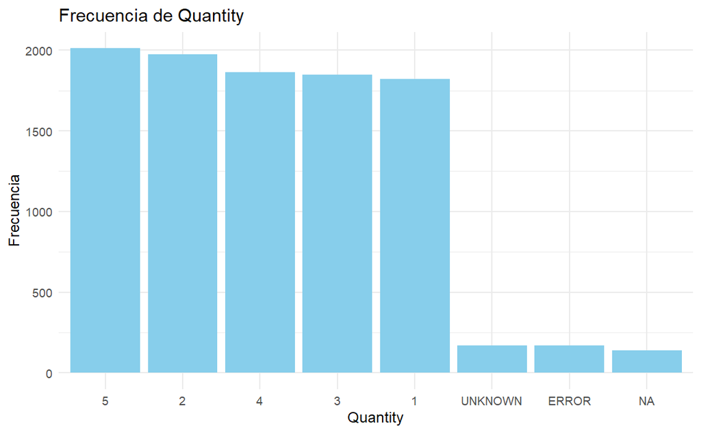

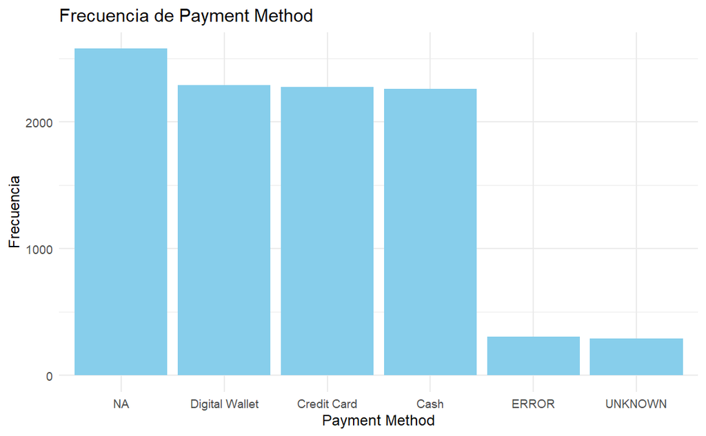

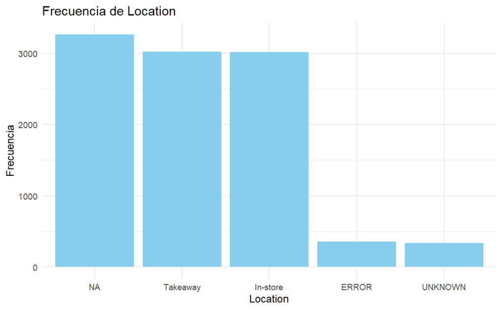

```r
cols <- c("Item", "Quantity", "Payment Method", "Location")

plot_column_summary <- function(df, col_name) {
  df <- df %>% mutate(temp = as.character(.data[[col_name]]))

  freq_table <- df %>%
    mutate(temp = if_else(is.na(temp), "NA", temp)) %>%
    group_by(temp) %>%
    summarize(count = n(), .groups = "drop") %>%
    arrange(desc(count))

  p_bar <- ggplot(freq_table, aes(x = reorder(temp, -count), y = count)) +
    geom_bar(stat = "identity", fill = "skyblue") +
    labs(title = paste("Frecuencia de", col_name),
         x = col_name,
         y = "Frecuencia") +
    theme_minimal()
  print(p_bar)


  special_counts <- df %>%
    summarize(NA_count = sum(is.na(.data[[col_name]])),
              ERROR_count = sum(.data[[col_name]] == "ERROR", na.rm = TRUE),
              UNKNOWN_count = sum(.data[[col_name]] == "UNKNOWN", na.rm = TRUE))

  print("Resumen de casos especiales")
  print(col_name)
  print(special_counts)

  cat("\n-------------------------------------------------------\n")
}

# Aplicar la función a cada columna
for (col in cols) {
  plot_column_summary(cafe_sales_df, col)
}
```

¿CUÁL ES EL ITEM (Coffee, Salad, Cake, etc) MÁS FRECUENTE EN LA TABLA? Juice

Cual es la Quantity (cantidad de items pedidos) menos frecuente? 1

Cuántas personas pagaron con cash?

```r
sum(cafe_sales_df$`Payment Method` == "Cash", na.rm = TRUE)
```

```
[1] 2258
```

2258

Cuantos unknown + NA + ERROR hay en la columna location? qué proporción representan estos valores no informativos de la totalidad de las filas del dataset?

```r
non_informative_count <- sum(cafe_sales_df$Location %in% c("UNKNOWN", "ERROR"), na.rm = TRUE)
nas_location <- sum(is.na(cafe_sales_df$Location))
print(non_informative_count + nas_location)
```

```
[1] 3961
```

```r
print((non_informative_count + nas_location) / length(cafe_sales_df$Location))
```

```
[1] 0.3961
```

3961 39.61%

```r
precioxunidad <- as.numeric(cafe_sales_df$`Price Per Unit`)
# Filtrar solo los valores numéricos (eliminando NA generados por conversión)
precioxunidadSinNA <- na.omit(precioxunidad)

promedio <- mean(precioxunidadSinNA, na.rm = TRUE)
mediana <- median(precioxunidadSinNA, na.rm = TRUE)
desvio <- sd(precioxunidadSinNA, na.rm = TRUE)

# Mostrar resultados
cat("Promedio:", round(promedio, 2), "\n")
```

```
Promedio: 2.95
```

```r
cat("Mediana:", round(mediana, 2), "\n")
```

```
Mediana: 3
```

```r
cat("Desvío Estándar:", round(desvio, 2), "\n")
```

```
Desvío Estándar: 1.28
```

Promedio: 2.95 Mediana: 3 Desvío Estándar: 1.28

Parte 2: Hay algun outlier en alguna columna? Porque? Justifique su respuesta.

En las columnas categoricas ya vimos que no, veamos price per unit y total spent

```r
table(cafe_sales_df$`Price Per Unit`)
```

```
    1.0     1.5     2.0     3.0     4.0     5.0   ERROR UNKNOWN
   1143    1133    1227    2429    2331    1204     190     164
```

```r
table(cafe_sales_df$`Total Spent`)
```

```
    1.0     1.5    10.0    12.0    15.0    16.0     2.0    20.0    25.0     3.0
    232     205     524     939     734     444     497     746     259     930
    4.0     4.5     5.0     6.0     7.5     8.0     9.0   ERROR UNKNOWN
    923     225     468     979     237     677     479     164     165
```

tampoco, DE REFERENCIA EL PROMEDIO DE total spent

```r
mean(as.numeric(cafe_sales_df$`Total Spent`), na.rm = T)
```

```
[1] 8.924352
```

Analizamos Transaction Date

```r
cafe_sales_df_original <- cafe_sales_df
cafe_sales_df_original
```

| Transaction ID | Item | Quantity | Price Per Unit | Total Spent | Payment Method | Location | Transaction Date |
| --- | --- | --- | --- | --- | --- | --- | --- |
| TXN_1961373 | Coffee | 2 | 2.0 | 4.0 | Credit Card | Takeaway | 2023-09-08 |
| TXN_4977031 | Cake | 4 | 3.0 | 12.0 | Cash | In-store | 2023-05-16 |
| TXN_4271903 | Cookie | 4 | 1.0 | ERROR | Credit Card | In-store | 2023-07-19 |
| TXN_7034554 | Salad | 2 | 5.0 | 10.0 | UNKNOWN | UNKNOWN | 2023-04-27 |
| TXN_3160411 | Coffee | 2 | 2.0 | 4.0 | Digital Wallet | In-store | 2023-06-11 |
| TXN_2602893 | Smoothie | 5 | 4.0 | 20.0 | Credit Card | NA | 2023-03-31 |
| TXN_4433211 | UNKNOWN | 3 | 3.0 | 9.0 | ERROR | Takeaway | 2023-10-06 |
| TXN_6699534 | Sandwich | 4 | 4.0 | 16.0 | Cash | UNKNOWN | 2023-10-28 |
| TXN_4717867 | NA | 5 | 3.0 | 15.0 | NA | Takeaway | 2023-07-28 |
| TXN_2064365 | Sandwich | 5 | 4.0 | 20.0 | NA | In-store | 2023-12-31 |

[output cut: 990 more lines]

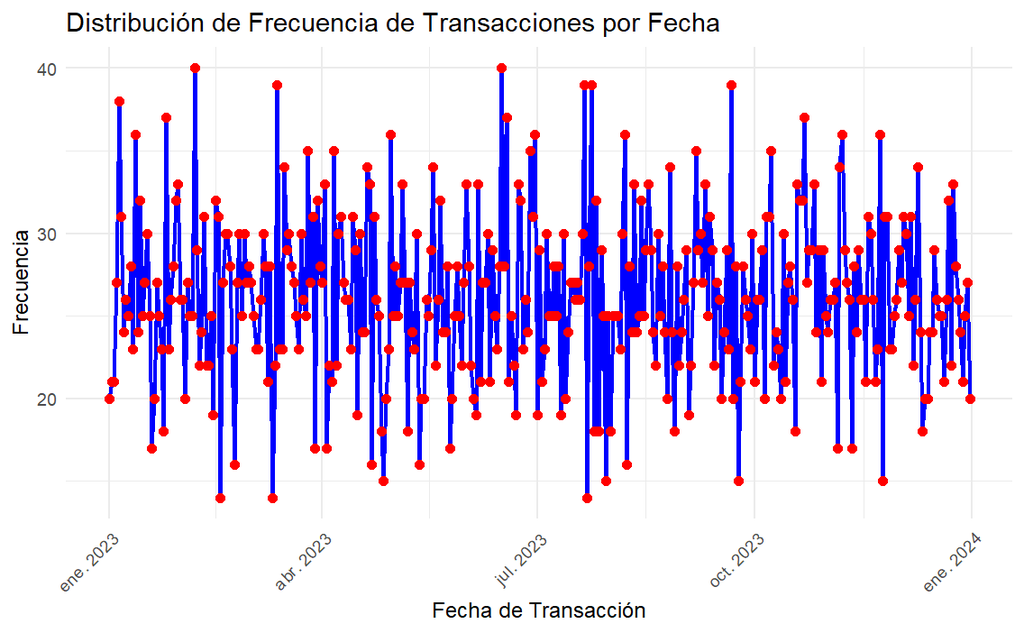

```r
cafe_sales_df <- cafe_sales_df %>%
  mutate(`Transaction Date` = as.Date(`Transaction Date`, format = "%Y-%m-%d")) %>%
  filter(!is.na(`Transaction Date`))

# Contar la frecuencia de transacciones por fecha
frecuencia_fechas <- cafe_sales_df %>%
  group_by(`Transaction Date`) %>%
  summarise(Frecuencia = n())

# Crear gráfico de distribución con ggplot
ggplot(frecuencia_fechas, aes(x = `Transaction Date`, y = Frecuencia)) +
  geom_line(color = "blue", size = 1) +  # Línea azul
  geom_point(color = "red", size = 2) +  # Puntos rojos en la línea
  labs(title = "Distribución de Frecuencia de Transacciones por Fecha",
       x = "Fecha de Transacción",
       y = "Frecuencia") +
  theme_minimal() +
  theme(axis.text.x = element_text(angle = 45, hjust = 1))  # Rotar etiquetas del eje X
```

Tampoco a nivel fechas

```r
cafe_sales_df
```

| Transaction ID | Item | Quantity | Price Per Unit | Total Spent | Payment Method | Location | Transaction Date |
| --- | --- | --- | --- | --- | --- | --- | --- |
| TXN_1961373 | Coffee | 2 | 2.0 | 4.0 | Credit Card | Takeaway | 2023-09-08 |
| TXN_4977031 | Cake | 4 | 3.0 | 12.0 | Cash | In-store | 2023-05-16 |
| TXN_4271903 | Cookie | 4 | 1.0 | ERROR | Credit Card | In-store | 2023-07-19 |
| TXN_7034554 | Salad | 2 | 5.0 | 10.0 | UNKNOWN | UNKNOWN | 2023-04-27 |
| TXN_3160411 | Coffee | 2 | 2.0 | 4.0 | Digital Wallet | In-store | 2023-06-11 |
| TXN_2602893 | Smoothie | 5 | 4.0 | 20.0 | Credit Card | NA | 2023-03-31 |
| TXN_4433211 | UNKNOWN | 3 | 3.0 | 9.0 | ERROR | Takeaway | 2023-10-06 |
| TXN_6699534 | Sandwich | 4 | 4.0 | 16.0 | Cash | UNKNOWN | 2023-10-28 |
| TXN_4717867 | NA | 5 | 3.0 | 15.0 | NA | Takeaway | 2023-07-28 |
| TXN_2064365 | Sandwich | 5 | 4.0 | 20.0 | NA | In-store | 2023-12-31 |

[output cut: 990 more lines]

No hay outliers.

```r
# 1. Convertir la columna 'Transaction Date' a Date y omitir los NA
cafe_sales_df <- cafe_sales_df %>%
  mutate(`Transaction Date` = as.Date(`Transaction Date`, format = "%Y-%m-%d")) %>%
  filter(!is.na(`Transaction Date`))

# 2. Crear la columna 'diaSemana' basada en el día del año, de forma cíclica
dias <- c("Domingo", "Lunes", "Martes", "Miércoles", "Jueves", "Viernes", "Sábado")

cafe_sales_df <- cafe_sales_df %>%
  mutate(
    dia_del_año = as.numeric(format(`Transaction Date`, "%j")),
    diaSemana = dias[((dia_del_año - 1) %% 7) + 1]
  )

# 3. Crear la columna 'mesDeVenta' y establecer el orden de enero a diciembre
orden_meses <- c("enero", "febrero", "marzo", "abril", "mayo", "junio",
                 "julio", "agosto", "septiembre", "octubre", "noviembre", "diciembre")

Sys.setlocale("LC_TIME", "es_ES.UTF-8")  # Set locale to Spanish
```

```
[1] "es_ES.UTF-8"
```

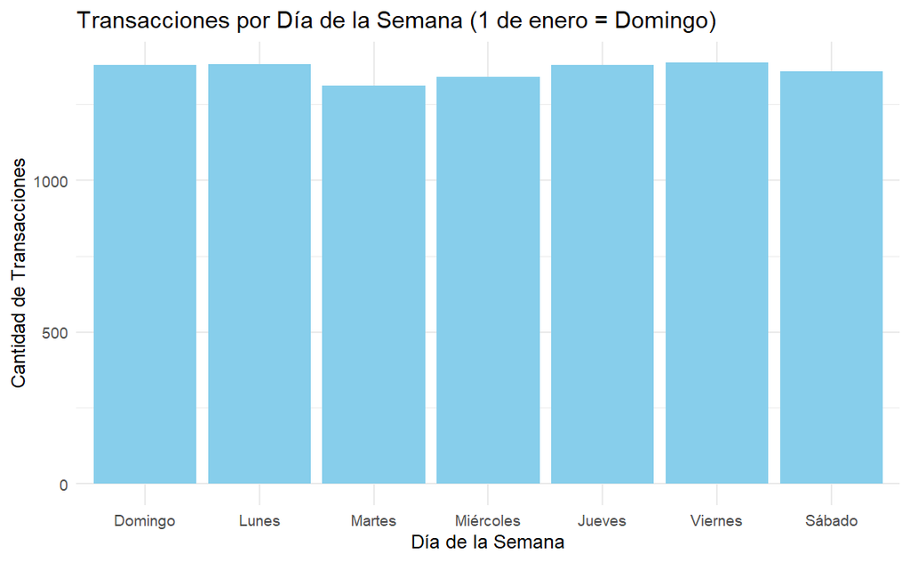

```r
cafe_sales_df <- cafe_sales_df %>%
  mutate(
    mesDeVenta = tolower(format(`Transaction Date`, "%B")),
    mesDeVenta = factor(mesDeVenta, levels = orden_meses, ordered = TRUE)
  )

cafe_sales_df <- cafe_sales_df %>%
  mutate(
    mesDeVenta = tolower(format(`Transaction Date`, "%B")),
    mesDeVenta = factor(mesDeVenta, levels = orden_meses, ordered = TRUE)
  )

# 4. Establecer el orden para los días de la semana (de Domingo a Sábado)
orden_dias <- dias  # ya en el orden deseado
cafe_sales_df <- cafe_sales_df %>%
  mutate(
    diaSemana = factor(diaSemana, levels = orden_dias, ordered = TRUE)
  )

# 5. Gráfico de barras: Número de transacciones por día de la semana
grafico_dias <- ggplot(cafe_sales_df, aes(x = diaSemana)) +
  geom_bar(fill = "skyblue") +
  labs(title = "Transacciones por Día de la Semana (1 de enero = Domingo)",
       x = "Día de la Semana",
       y = "Cantidad de Transacciones") +
  theme_minimal()

print(grafico_dias)
```

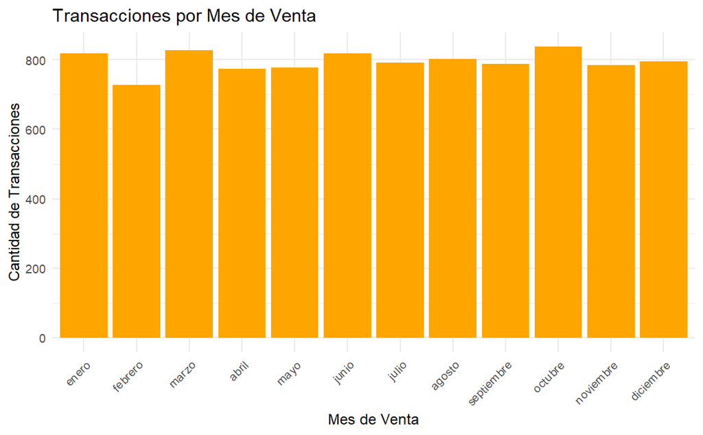

```r
# 6. Gráfico de barras: Número de transacciones por mes de venta (mesDeVenta)
grafico_meses <- ggplot(cafe_sales_df, aes(x = mesDeVenta)) +
  geom_bar(fill = "orange") +
  labs(title = "Transacciones por Mes de Venta",
       x = "Mes de Venta",
       y = "Cantidad de Transacciones") +
  theme_minimal() +
  theme(axis.text.x = element_text(angle = 45, hjust = 1))

print(grafico_meses)
```

Sabiendo qué el 1 de enero de 2023 fue Domingo. Cual es el dia de la semana con menos transacciones? Cuál fue el dia de la semana con más transacciones?

```r
# Calcular el número de transacciones por día de la semana
ventas_por_dia <- cafe_sales_df %>%
  group_by(diaSemana) %>%
  summarise(cantidad = n())

# Extraer el día con mayor cantidad de ventas
dia_max <- ventas_por_dia %>% filter(cantidad == max(cantidad))

# Extraer el día con menor cantidad de filas
dia_min <- ventas_por_dia %>% filter(cantidad == min(cantidad))

print("Día de la semana con más ventas:")
```

```
[1] "Día de la semana con más ventas:"
```

```r
print(dia_max)
```

| diaSemana | cantidad |
| --- | --- |
| Viernes | 1388 |

```r
print("Día de la semana con menos filas:")
```

```
[1] "Día de la semana con menos filas:"
```

```r
print(dia_min)
```

| diaSemana | cantidad |
| --- | --- |
| Martes | 1311 |

Dia con menos Martes 1311 dia con mas Viernes 1388

```r
# Calcular el número de transacciones por mes
ventas_por_mes <- cafe_sales_df %>%
  group_by(mesDeVenta) %>%
  summarise(cantidad = n())

# Extraer el mes con mayor número de transacciones
mes_max <- ventas_por_mes %>% filter(cantidad == max(cantidad))
mes_min <- ventas_por_mes %>% filter(cantidad == min(cantidad))

print("Mes con más transacciones:")
```

```
[1] "Mes con más transacciones:"
```

```r
print(mes_max)
```

| mesDeVenta | cantidad |
| --- | --- |
| octubre | 838 |

```r
print("Mes con menos transacciones:")
```

```
[1] "Mes con menos transacciones:"
```

```r
print(mes_min)
```

| mesDeVenta | cantidad |
| --- | --- |
| febrero | 727 |

Mes con menos transacciones Febrero 727 Mes con mas transacciones octubre 838

```r
cafe_sales_df <- cafe_sales_df_original
cafe_sales_df$`Price Per Unit` <- as.numeric(cafe_sales_df$`Price Per Unit`)
df_filtrado <- cafe_sales_df %>%
  filter(!Item %in% c("ERROR", "UNKNOWN", NA))
# 1) Verificar si cada Item tiene un precio unitario consistente, ignorando los NA
consistencia <- df_filtrado %>%
  group_by(Item) %>%
  summarise(n_precios = n_distinct(`Price Per Unit`, na.rm = TRUE))

print(consistencia)
```

| Item | n_precios |
| --- | --- |
| Cake | 1 |
| Coffee | 1 |
| Cookie | 1 |
| Juice | 1 |
| Salad | 1 |
| Sandwich | 1 |
| Smoothie | 1 |
| Tea | 1 |

```r
# Verificar si todos tienen exactamente un precio único (excluyendo los NA)
todos_consistentes <- all(consistencia$n_precios == 1)

if (todos_consistentes) {
  print("Todos los items tienen un precio unitario consistente.")

  # 2) Crear diccionario: un vector nombrado con el precio por cada Item, omitiendo los NA
  dict_precios <- cafe_sales_df %>%
    group_by(Item) %>%
    summarise(precio = first(na.omit(`Price Per Unit`))) %>%
    deframe()  # Convierte el dataframe en un vector nombrado

  print(dict_precios)

} else {
  print("No todos los items tienen un precio unitario consistente.")
}
```

```
[1] "Todos los items tienen un precio unitario consistente."
    Cake   Coffee   Cookie    ERROR    Juice    Salad Sandwich Smoothie      Tea
     3.0      2.0      1.0      1.5      3.0      5.0      4.0      4.0      1.5
 UNKNOWN     <NA>
     3.0      3.0
```

```r
table(cafe_sales_df[cafe_sales_df$Item == "Coffee", ]$`Price Per Unit`)
```

```
   2
1069
```

```r
library(dplyr)

# Definimos el menú como un vector nombrado (clave = Item, valor = Price Per Unit)
menu <- c("Cake" = 3,
          "Juice" = 3,
          "Coffee" = 2,
          "Cookie" = 1,
          "Salad" = 5,
          "Sandwich" = 4,
          "Smoothie" = 4,
          "Tea" = 2)

# Convertir Price Per Unit a numérico; los valores no numéricos (como "ERROR" o "UNKNOWN") pasarán a NA
cafe_sales_df$`Price Per Unit` <- as.numeric(cafe_sales_df$`Price Per Unit`)

# Actualizar Price Per Unit cuando este es NA y el Item es válido (no NA, "ERROR" ni "UNKNOWN")
cafe_sales_df <- cafe_sales_df %>%
  mutate(`Price Per Unit` = if_else(
    is.na(`Price Per Unit`) & !is.na(Item) & !(Item %in% c("ERROR", "UNKNOWN")),
    as.numeric(menu[Item]),
    `Price Per Unit`
  ))

# Visualizar el data frame resultante (opcional)
print(cafe_sales_df)
```

| Transaction ID | Item | Quantity | Price Per Unit | Total Spent | Payment Method | Location | Transaction Date |
| --- | --- | --- | --- | --- | --- | --- | --- |
| TXN_1961373 | Coffee | 2 | 2.0 | 4.0 | Credit Card | Takeaway | 2023-09-08 |
| TXN_4977031 | Cake | 4 | 3.0 | 12.0 | Cash | In-store | 2023-05-16 |
| TXN_4271903 | Cookie | 4 | 1.0 | ERROR | Credit Card | In-store | 2023-07-19 |
| TXN_7034554 | Salad | 2 | 5.0 | 10.0 | UNKNOWN | UNKNOWN | 2023-04-27 |
| TXN_3160411 | Coffee | 2 | 2.0 | 4.0 | Digital Wallet | In-store | 2023-06-11 |
| TXN_2602893 | Smoothie | 5 | 4.0 | 20.0 | Credit Card | NA | 2023-03-31 |
| TXN_4433211 | UNKNOWN | 3 | 3.0 | 9.0 | ERROR | Takeaway | 2023-10-06 |
| TXN_6699534 | Sandwich | 4 | 4.0 | 16.0 | Cash | UNKNOWN | 2023-10-28 |
| TXN_4717867 | NA | 5 | 3.0 | 15.0 | NA | Takeaway | 2023-07-28 |
| TXN_2064365 | Sandwich | 5 | 4.0 | 20.0 | NA | In-store | 2023-12-31 |

[output cut: 990 more lines]

```r
NA
```

```r
# Convertir las columnas a numérico para asegurar que las operaciones sean válidas.
cafe_sales_df <- cafe_sales_df %>%
  mutate(
    Quantity = as.numeric(Quantity),
    `Price Per Unit` = as.numeric(`Price Per Unit`),
    `Total Spent` = as.numeric(`Total Spent`)
  )
# Completar las columnas faltantes basándose en la relación: Quantity * Price Per Unit = Total Spent
cafe_sales_df <- cafe_sales_df %>%
  mutate(
    # Calcular Quantity cuando falte y las otras dos estén presentes.
    Quantity = if_else(
      is.na(Quantity) & !is.na(`Price Per Unit`) & !is.na(`Total Spent`),
      `Total Spent` / `Price Per Unit`,
      Quantity
    ),
    # Calcular Price Per Unit cuando falte y las otras dos estén presentes.
    `Price Per Unit` = if_else(
      is.na(`Price Per Unit`) & !is.na(Quantity) & !is.na(`Total Spent`),
      `Total Spent` / Quantity,
      `Price Per Unit`
    ),
    # Calcular Total Spent cuando falte y las otras dos estén presentes.
    `Total Spent` = if_else(
      is.na(`Total Spent`) & !is.na(Quantity) & !is.na(`Price Per Unit`),
      Quantity * `Price Per Unit`,
      `Total Spent`
    )
  )

# Visualizar el data frame resultante (opcional)
print(cafe_sales_df)
```

| Transaction ID | Item | Quantity | Price Per Unit | Total Spent | Payment Method | Location | Transaction Date |
| --- | --- | --- | --- | --- | --- | --- | --- |
| TXN_1961373 | Coffee | 2 | 2.0 | 4.0 | Credit Card | Takeaway | 2023-09-08 |
| TXN_4977031 | Cake | 4 | 3.0 | 12.0 | Cash | In-store | 2023-05-16 |
| TXN_4271903 | Cookie | 4 | 1.0 | 4.0 | Credit Card | In-store | 2023-07-19 |
| TXN_7034554 | Salad | 2 | 5.0 | 10.0 | UNKNOWN | UNKNOWN | 2023-04-27 |
| TXN_3160411 | Coffee | 2 | 2.0 | 4.0 | Digital Wallet | In-store | 2023-06-11 |
| TXN_2602893 | Smoothie | 5 | 4.0 | 20.0 | Credit Card | NA | 2023-03-31 |
| TXN_4433211 | UNKNOWN | 3 | 3.0 | 9.0 | ERROR | Takeaway | 2023-10-06 |
| TXN_6699534 | Sandwich | 4 | 4.0 | 16.0 | Cash | UNKNOWN | 2023-10-28 |
| TXN_4717867 | NA | 5 | 3.0 | 15.0 | NA | Takeaway | 2023-07-28 |
| TXN_2064365 | Sandwich | 5 | 4.0 | 20.0 | NA | In-store | 2023-12-31 |

[output cut: 990 more lines]

```r
NA
```

```r
# Creamos un diccionario inverso a partir del menú:
# Para precios repetidos se toma el primer valor en el orden del menú.
price_to_item <- c("1" = "Cookie",
                   "2" = "Coffee",   # Para precio 2 se asigna "Coffee" (primero en el menú)
                   "3" = "Cake",     # Para precio 3 se asigna "Cake"
                   "4" = "Sandwich", # Para precio 4 se asigna "Sandwich"
                   "5" = "Salad")

# Completar la columna Item cuando esté ausente o contenga "ERROR" o "UNKNOWN" y el Price Per Unit esté disponible
cafe_sales_df <- cafe_sales_df %>%
  mutate(
    Item = if_else(
      (is.na(Item) | Item %in% c("ERROR", "UNKNOWN")) & !is.na(`Price Per Unit`),
      price_to_item[as.character(`Price Per Unit`)],
      Item
    )
  )

# Visualizar el data frame resultante (opcional)
print(cafe_sales_df)
```

| Transaction ID | Item | Quantity | Price Per Unit | Total Spent | Payment Method | Location | Transaction Date |
| --- | --- | --- | --- | --- | --- | --- | --- |
| TXN_1961373 | Coffee | 2 | 2.0 | 4.0 | Credit Card | Takeaway | 2023-09-08 |
| TXN_4977031 | Cake | 4 | 3.0 | 12.0 | Cash | In-store | 2023-05-16 |
| TXN_4271903 | Cookie | 4 | 1.0 | 4.0 | Credit Card | In-store | 2023-07-19 |
| TXN_7034554 | Salad | 2 | 5.0 | 10.0 | UNKNOWN | UNKNOWN | 2023-04-27 |
| TXN_3160411 | Coffee | 2 | 2.0 | 4.0 | Digital Wallet | In-store | 2023-06-11 |
| TXN_2602893 | Smoothie | 5 | 4.0 | 20.0 | Credit Card | NA | 2023-03-31 |
| TXN_4433211 | Cake | 3 | 3.0 | 9.0 | ERROR | Takeaway | 2023-10-06 |
| TXN_6699534 | Sandwich | 4 | 4.0 | 16.0 | Cash | UNKNOWN | 2023-10-28 |
| TXN_4717867 | Cake | 5 | 3.0 | 15.0 | NA | Takeaway | 2023-07-28 |
| TXN_2064365 | Sandwich | 5 | 4.0 | 20.0 | NA | In-store | 2023-12-31 |

[output cut: 990 more lines]

```r
NA
```

```r
# Calcular la cantidad de NA en cada columna
na_counts <- sapply(cafe_sales_df, function(x) sum(is.na(x)))

# Calcular la cantidad de "ERROR" en cada columna (se convierten a carácter para evitar problemas)
error_counts <- sapply(cafe_sales_df, function(x) sum(as.character(x) == "ERROR", na.rm = TRUE))

# Calcular la cantidad de "UNKNOWN" en cada columna (se convierten a carácter para evitar problemas)
unknown_counts <- sapply(cafe_sales_df, function(x) sum(as.character(x) == "UNKNOWN", na.rm = TRUE))

# Unir las cuentas en una matriz usando nombres de fila entre comillas
result_matrix <- rbind("NA" = na_counts, "ERROR" = error_counts, "UNKNOWN" = unknown_counts)

# Visualizar la matriz resultante
print(result_matrix)
```

```
        Transaction ID Item Quantity Price Per Unit Total Spent Payment Method
NA                   0  120       23              6          23           2579
ERROR                0    2        0              0           0            306
UNKNOWN              0    2        0              0           0            293
        Location Transaction Date
NA          3265              159
ERROR        358              142
UNKNOWN      338              159
```

```r
cafe_sales_df
```

| Transaction ID | Item | Quantity | Price Per Unit | Total Spent | Payment Method | Location | Transaction Date |
| --- | --- | --- | --- | --- | --- | --- | --- |
| TXN_1961373 | Coffee | 2 | 2.0 | 4.0 | Credit Card | Takeaway | 2023-09-08 |
| TXN_4977031 | Cake | 4 | 3.0 | 12.0 | Cash | In-store | 2023-05-16 |
| TXN_4271903 | Cookie | 4 | 1.0 | 4.0 | Credit Card | In-store | 2023-07-19 |
| TXN_7034554 | Salad | 2 | 5.0 | 10.0 | UNKNOWN | UNKNOWN | 2023-04-27 |
| TXN_3160411 | Coffee | 2 | 2.0 | 4.0 | Digital Wallet | In-store | 2023-06-11 |
| TXN_2602893 | Smoothie | 5 | 4.0 | 20.0 | Credit Card | NA | 2023-03-31 |
| TXN_4433211 | Cake | 3 | 3.0 | 9.0 | ERROR | Takeaway | 2023-10-06 |
| TXN_6699534 | Sandwich | 4 | 4.0 | 16.0 | Cash | UNKNOWN | 2023-10-28 |
| TXN_4717867 | Cake | 5 | 3.0 | 15.0 | NA | Takeaway | 2023-07-28 |
| TXN_2064365 | Sandwich | 5 | 4.0 | 20.0 | NA | In-store | 2023-12-31 |

[output cut: 990 more lines]

```r
NA
```

```r
library(dplyr)

# Vector de columnas a rellenar
cols_a_rellenar <- c("Item", "Quantity", "Price Per Unit", "Total Spent",
                       "Payment Method", "Location", "Transaction Date")

# Función para calcular la moda (valor más frecuente) excluyendo NA, "ERROR" y "UNKNOWN"
calcular_moda <- function(x) {
  x_char <- as.character(x)
  # Filtrar valores válidos
  validos <- x_char[!is.na(x_char) & !(x_char %in% c("ERROR", "UNKNOWN"))]
  if (length(validos) == 0) return(NA)
  tab <- table(validos)
  moda <- names(tab)[which.max(tab)]
  return(moda)
}

# Función para reemplazar los valores NA, "ERROR" y "UNKNOWN" por la moda de la columna.
# Se adapta al tipo de dato: si es numérico, se convierte la moda a número.
reemplazar_con_moda <- function(x, moda) {
  if (is.na(moda)) return(x)
  if (is.numeric(x)) {
    moda_num <- as.numeric(moda)
    x[is.na(x) | x %in% c("ERROR", "UNKNOWN")] <- moda_num
  } else {
    x <- as.character(x)
    x[is.na(x) | x %in% c("ERROR", "UNKNOWN")] <- moda
  }
  return(x)
}

# Calcular la moda para cada columna
modas <- sapply(cafe_sales_df[cols_a_rellenar], calcular_moda)

# Reemplazar en cada columna los valores no válidos por la moda correspondiente
for (col in cols_a_rellenar) {
  moda <- modas[[col]]
  cafe_sales_df[[col]] <- reemplazar_con_moda(cafe_sales_df[[col]], moda)
}

# Visualizar el data frame actualizado
print(cafe_sales_df)
```

| Transaction ID | Item | Quantity | Price Per Unit | Total Spent | Payment Method | Location | Transaction Date |
| --- | --- | --- | --- | --- | --- | --- | --- |
| TXN_1961373 | Coffee | 2 | 2.0 | 4.0 | Credit Card | Takeaway | 2023-09-08 |
| TXN_4977031 | Cake | 4 | 3.0 | 12.0 | Cash | In-store | 2023-05-16 |
| TXN_4271903 | Cookie | 4 | 1.0 | 4.0 | Credit Card | In-store | 2023-07-19 |
| TXN_7034554 | Salad | 2 | 5.0 | 10.0 | Digital Wallet | Takeaway | 2023-04-27 |
| TXN_3160411 | Coffee | 2 | 2.0 | 4.0 | Digital Wallet | In-store | 2023-06-11 |
| TXN_2602893 | Smoothie | 5 | 4.0 | 20.0 | Credit Card | Takeaway | 2023-03-31 |
| TXN_4433211 | Cake | 3 | 3.0 | 9.0 | Digital Wallet | Takeaway | 2023-10-06 |
| TXN_6699534 | Sandwich | 4 | 4.0 | 16.0 | Cash | Takeaway | 2023-10-28 |
| TXN_4717867 | Cake | 5 | 3.0 | 15.0 | Digital Wallet | Takeaway | 2023-07-28 |
| TXN_2064365 | Sandwich | 5 | 4.0 | 20.0 | Digital Wallet | In-store | 2023-12-31 |

[output cut: 990 more lines]

```r
NA
```

```r
# Calcular la cantidad de NA en cada columna
na_counts <- sapply(cafe_sales_df, function(x) sum(is.na(x)))

# Calcular la cantidad de "ERROR" en cada columna (se convierten a carácter para evitar problemas)
error_counts <- sapply(cafe_sales_df, function(x) sum(as.character(x) == "ERROR", na.rm = TRUE))

# Calcular la cantidad de "UNKNOWN" en cada columna (se convierten a carácter para evitar problemas)
unknown_counts <- sapply(cafe_sales_df, function(x) sum(as.character(x) == "UNKNOWN", na.rm = TRUE))

# Unir las cuentas en una matriz usando nombres de fila entre comillas
result_matrix <- rbind("NA" = na_counts, "ERROR" = error_counts, "UNKNOWN" = unknown_counts)

# Visualizar la matriz resultante
print(result_matrix)
```

```
        Transaction ID Item Quantity Price Per Unit Total Spent Payment Method
NA                   0    0        0              0           0              0
ERROR                0    0        0              0           0              0
UNKNOWN              0    0        0              0           0              0
        Location Transaction Date
NA             0                0
ERROR          0                0
UNKNOWN        0                0
```

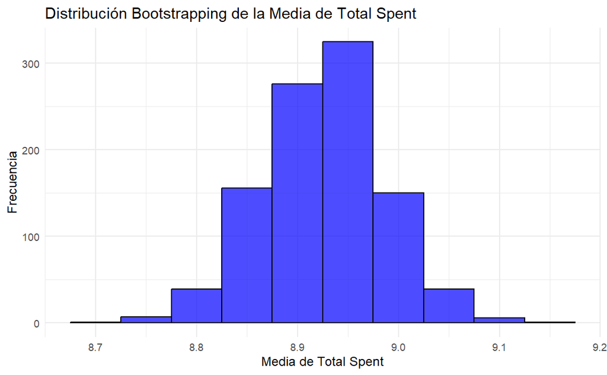

```r
# Parte 4: Análisis con Bootstrapping, división en bloques y visualización con ggplot

# 1. Setear la semilla de aleatoriedad
set.seed(123)

# 2. Bootstrapping: generar la distribución de la media de "Total Spent"
# Resampleamos con reemplazo 1000 veces tomando todas las filas y calculando la media de Total Spent
n_bootstrap <- 1000
bootstrap_means <- replicate(n_bootstrap, {
  muestra <- sample(cafe_sales_df$`Total Spent`, size = nrow(cafe_sales_df), replace = TRUE)
  mean(muestra)
})
bootstrap_df <- data.frame(MeanTotalSpent = bootstrap_means)

# Graficar la distribución de las medias bootstrappeadas
library(ggplot2)
p1 <- ggplot(bootstrap_df, aes(x = MeanTotalSpent)) +
  geom_histogram(binwidth = 0.05, fill = "blue", color = "black", alpha = 0.7) +
  labs(title = "Distribución Bootstrapping de la Media de Total Spent",
       x = "Media de Total Spent", y = "Frecuencia") +
  theme_minimal()
print(p1)
```

```r
# 3. Dividir el dataset en 3 bloques sin repetición: 8000, 1000 y 1000
# Primero, se mezclan aleatoriamente las filas
cafe_sales_df_shuffled <- cafe_sales_df[sample(nrow(cafe_sales_df)), ]
n_total <- nrow(cafe_sales_df_shuffled)

if(n_total >= 10000) {
  block1 <- cafe_sales_df_shuffled[1:8000, ]
  block2 <- cafe_sales_df_shuffled[8001:9000, ]
  block3 <- cafe_sales_df_shuffled[9001:10000, ]

  # Comparar estadísticas (media, mediana y desviación estándar) de "Total Spent" en cada bloque
  stats <- data.frame(
    Bloque = c("Block1", "Block2", "Block3"),
    Media = c(mean(block1$`Total Spent`),
              mean(block2$`Total Spent`),
              mean(block3$`Total Spent`)),
    Mediana = c(median(block1$`Total Spent`),
                median(block2$`Total Spent`),
                median(block3$`Total Spent`)),
    SD = c(sd(block1$`Total Spent`),
           sd(block2$`Total Spent`),
           sd(block3$`Total Spent`))
  )

  print(stats)
} else {
  message("El dataset no tiene al menos 10000 filas, no es posible realizar la división en bloques.")
}
```

| Bloque | Media | Mediana | SD |
| --- | --- | --- | --- |
| Block1 | 8.875438 | 8 | 5.985424 |
| Block2 | 9.084000 | 8 | 6.084815 |
| Block3 | 9.149500 | 8 | 6.023262 |

```r
NA
```

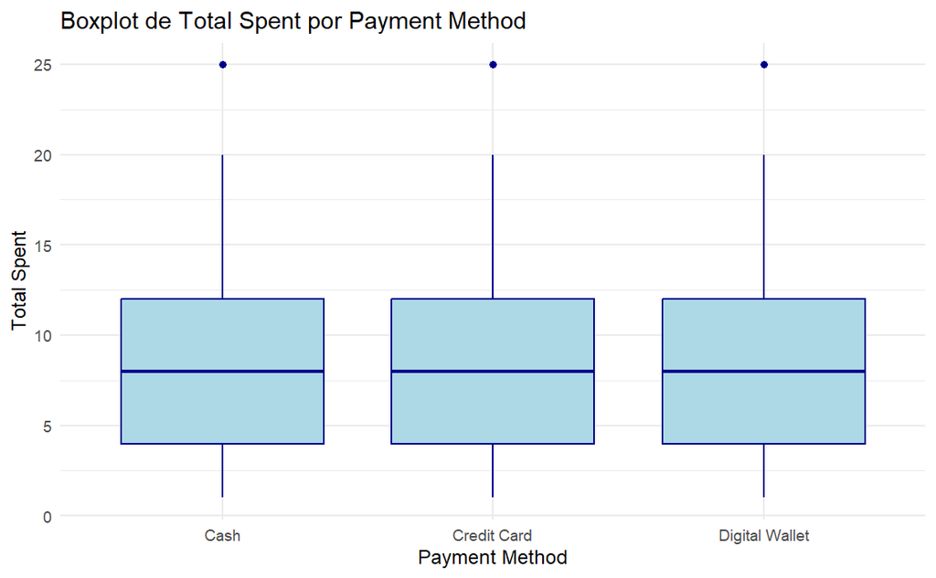

```r
# 4. Visualización adicional utilizando ggplot:
# Ejemplo: Boxplot de "Total Spent" según "Payment Method"
p2 <- ggplot(cafe_sales_df, aes(x = `Payment Method`, y = `Total Spent`)) +
  geom_boxplot(fill = "lightblue", color = "darkblue") +
  labs(title = "Boxplot de Total Spent por Payment Method",
       x = "Payment Method", y = "Total Spent") +
  theme_minimal()
print(p2)
```